# Exploratory Data Analysis of Ford GoBike System

## by Ebele Shaba

## Visualization Group A

> Bar charts were plotted for the variables of interest. For the user_type, it can be seen for the chart that majority of them are suscribers, it may mean that their policicies on suscription are more favourable to users. The bar chart also shows that they have more male users that other gender types, which can be for differnt reasons which more features can help solve. Finally, for the member_birth_year, the chart displayes a curve with majority of users born between 1980 and 1998 with the highest peaks in 1988 and 1993.

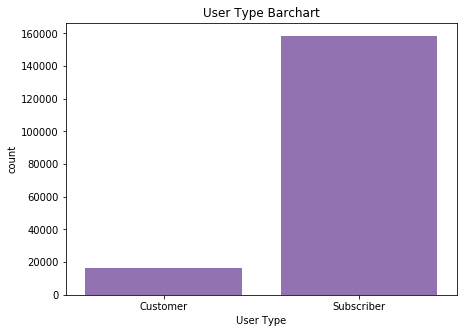

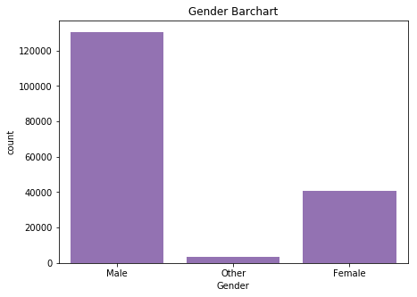

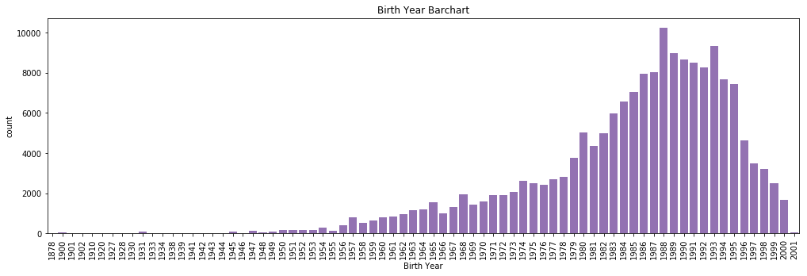

## Visualization Group B

> There were some unsual behaviour in the histograms for duration_sec with long tails of outliers in the plot a closer look was taken by reducting the x-axis limits however this was still flawed representaion of the plot. Eventually, the log of the duration_sec was taken and plotted to generate a better looking normalized plot.

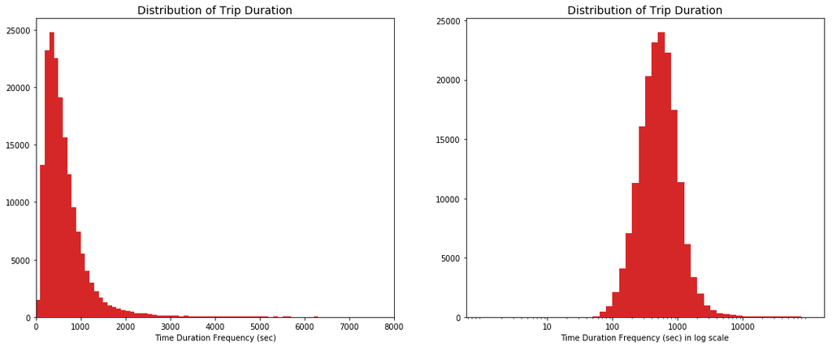

## Visualization Group C

> The behaviour of user_type was introduced in the univariate analysis, were most of the users were subscribers, the same goes here. In addition an increase can be seen in the number of all member_gender types from customers to subscribers. The bar chart was also created for the user_type and bike_share_for_all_trip to note sharing behaviour.it can be noted that no customer engages in bike sharing, while a low amount of subscribers do.

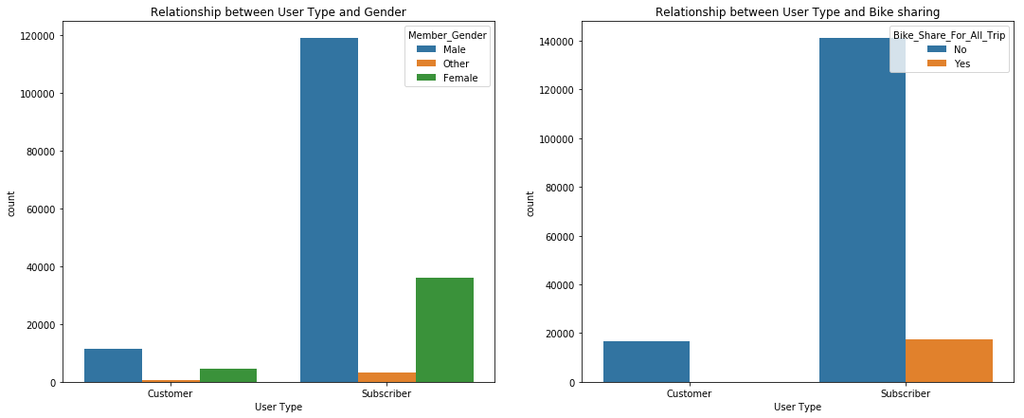

## Visualization Group D

> Violin and box plots were created to depict relationship between age and user_type, the two plots show that a large number of users are between the ages of 20 to 60 and this is similar for both of the user_type. There is regardless of the user_type a certain age range uses the bike system more.

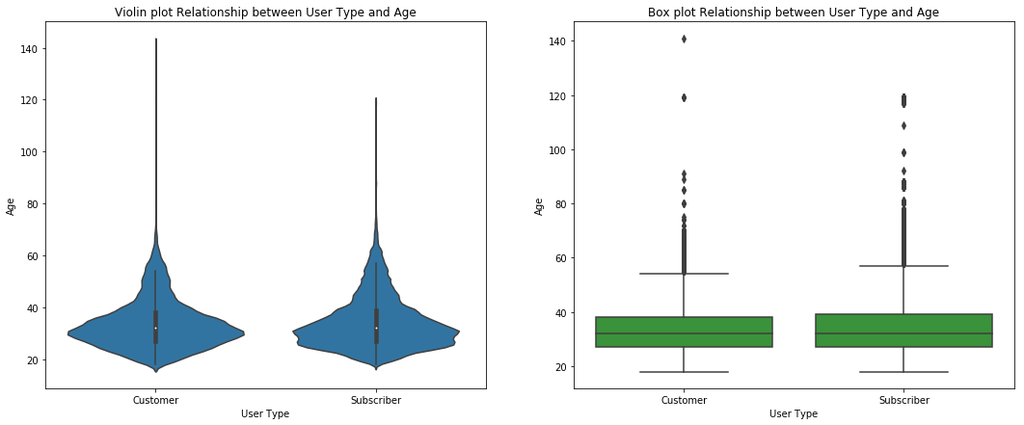

## Visualization Group E

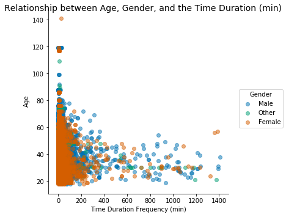

## Key Insights for Presentation

> This project succeeded in giving some valuable insights on the way the Ford goBike System works. One major insight derived from the data is one the user type, after various plots from univariate to multivariate methods it show clearly that majority of users are subscribers regardless of their age or gender. This may mean that their policicies on suscription are more favourable to users and therefore should be continued. What is also interesting to note is regardless of the gender the age ranges do not differ too or vice versa. The above can be used in addition with other features to create business policies that can target users. Therefore, in case of advertisement, whom should ford target? Male subscribers i.e. with subscription model within ages 20 to 60(except they have a data driven market for females or other gender types within the same age range and user model). Data wrangling, data visualisation, and feature engineering techniques were performed in the project.